# DL_ye

Ye

2024-03-26

Let’s start by preparing the data by splitting with testid

```r
# Remove rows with missing values from the dataset
Gitters <- na.omit(Hitters)

n <- nrow(Gitters)
set.seed(13)
ntest <- n/3

# Randomly sample row indices to create the test dataset
testid <- sample(1:n, ntest)
```

Fitting the model into a linear model

```r
lfit <- lm(Salary ~ ., data = Gitters[-testid , ])

#Prediction
lpred <- predict(lfit, Gitters[testid , ])

#MEan Absolute Prediction error between train and test data.
with(Gitters[testid , ], mean(abs(lpred - Salary)))
```

```
## [1] 254.6687
```

Cross-validated lasso regression model using cv.glmnet Getting MAE from lasso regression model

```r
#Scaling the predictors
x <- scale(model.matrix(Salary ~ . - 1, data = Gitters))
y <- Gitters$Salary

#Fitting into Lasso regression
cvfit <- cv.glmnet(x[-testid , ], y[-testid],type.measure = "mae")

#Prediction
cpred <- predict(cvfit , x[testid , ])

#MAE
mean(abs(y[testid] - cpred))
```

```
## [1] 288.9544
```

## Single Layer Neural Network

To fit the neural network, we have to set up a model structure that describe the network.

keras_model_sequential(): This function initializes an empty sequential model, which is a linear stack of layers. layer_dense: This function adds a fully connected (dense) layer to the neural network.

layer_dropout : This function adds a dropout layer to the neural network. Dropout is a regularization technique used to prevent overfitting by randomly setting a fraction of input units to zero during training. layer_dense: output layer for linear regression. It connects the layer with a single neuron, which is typical for linear regression.

```r
modnn <- keras_model_sequential() %>%
  layer_dense(units = 50, activation = "sigmoid",input_shape = ncol(x)) %>%
  layer_dropout(rate = 0.4) %>%
  layer_dense(units = 1)


x <- model.matrix(Salary ~ . - 1, data = Gitters) %>% scale()
modnn
```

```
## Model: "sequential"
## ________________________________________________________________________________
##  Layer (type)                       Output Shape                    Param #
## ================================================================================
##  dense_1 (Dense)                    (None, 50)                      1050
##  dropout (Dropout)                  (None, 50)                      0
##  dense (Dense)                      (None, 1)                       51
## ================================================================================
## Total params: 1101 (4.30 KB)
## Trainable params: 1101 (4.30 KB)
## Non-trainable params: 0 (0.00 Byte)
## ________________________________________________________________________________
```

Optimizer is an optimization algorithm that adjust the learning rate for each parameter based on the average fo recent gradients.

Then, we fit the model into a plot.

Epochs: the number of epochs or iterations over the entire dataset during the training. batch_size: the algorithm randomly select this amount of training observations for the computation of the gradient(how much we need to adjust).

```r
modnn %>% compile(
  loss = "mse",
  optimizer = optimizer_rmsprop(),
  metrics = list("mean_absolute_error")
)

history <- modnn %>%
  fit(
    x[-testid , ], y[-testid], epochs = 400, batch_size = 32, validation_data = list(x[testid , ], y[testid])
    )
```

```
## 6/6 - 2s - loss: 456771.0000 - mean_absolute_error: 533.6399 - val_loss: 555720.6250 - val_mean_absolute_error: 539.4483 - 2s/epoch - 267ms/step
## 6/6 - 0s - loss: 456450.9688 - mean_absolute_error: 533.4000 - val_loss: 555444.8125 - val_mean_absolute_error: 539.2547 - 117ms/epoch - 20ms/step
## 6/6 - 0s - loss: 456244.6250 - mean_absolute_error: 533.2188 - val_loss: 555202.0000 - val_mean_absolute_error: 539.0798 - 101ms/epoch - 17ms/step
## 6/6 - 0s - loss: 456026.4062 - mean_absolute_error: 533.0293 - val_loss: 554969.5625 - val_mean_absolute_error: 538.9143 - 112ms/epoch - 19ms/step
## 6/6 - 0s - loss: 455776.5312 - mean_absolute_error: 532.8589 - val_loss: 554742.8750 - val_mean_absolute_error: 538.7546 - 100ms/epoch - 17ms/step
## 6/6 - 0s - loss: 455761.5000 - mean_absolute_error: 532.7197 - val_loss: 554506.5000 - val_mean_absolute_error: 538.5891 - 97ms/epoch - 16ms/step
## 6/6 - 0s - loss: 455331.0938 - mean_absolute_error: 532.5152 - val_loss: 554294.8750 - val_mean_absolute_error: 538.4368 - 95ms/epoch - 16ms/step
## 6/6 - 0s - loss: 455229.4688 - mean_absolute_error: 532.3942 - val_loss: 554078.6875 - val_mean_absolute_error: 538.2826 - 95ms/epoch - 16ms/step
## 6/6 - 0s - loss: 454971.4062 - mean_absolute_error: 532.2094 - val_loss: 553866.9375 - val_mean_absolute_error: 538.1305 - 97ms/epoch - 16ms/step
## 6/6 - 0s - loss: 454777.7812 - mean_absolute_error: 532.0445 - val_loss: 553639.3750 - val_mean_absolute_error: 537.9702 - 97ms/epoch - 16ms/step
## 6/6 - 0s - loss: 454604.0938 - mean_absolute_error: 531.8873 - val_loss: 553425.1875 - val_mean_absolute_error: 537.8188 - 97ms/epoch - 16ms/step
## 6/6 - 0s - loss: 454361.0938 - mean_absolute_error: 531.7166 - val_loss: 553216.0000 - val_mean_absolute_error: 537.6652 - 98ms/epoch - 16ms/step
## 6/6 - 0s - loss: 454205.5000 - mean_absolute_error: 531.5878 - val_loss: 552995.3125 - val_mean_absolute_error: 537.5065 - 96ms/epoch - 16ms/step
## 6/6 - 0s - loss: 453884.5312 - mean_absolute_error: 531.3697 - val_loss: 552776.6250 - val_mean_absolute_error: 537.3503 - 97ms/epoch - 16ms/step
## 6/6 - 0s - loss: 453678.3750 - mean_absolute_error: 531.2045 - val_loss: 552550.5625 - val_mean_absolute_error: 537.1926 - 97ms/epoch - 16ms/step
## 6/6 - 0s - loss: 453561.0312 - mean_absolute_error: 531.0376 - val_loss: 552347.0625 - val_mean_absolute_error: 537.0464 - 94ms/epoch - 16ms/step
## 6/6 - 0s - loss: 453360.0938 - mean_absolute_error: 530.8983 - val_loss: 552129.5000 - val_mean_absolute_error: 536.8947 - 94ms/epoch - 16ms/step
## 6/6 - 0s - loss: 453182.6250 - mean_absolute_error: 530.7582 - val_loss: 551913.0000 - val_mean_absolute_error: 536.7411 - 96ms/epoch - 16ms/step
## 6/6 - 0s - loss: 452964.7188 - mean_absolute_error: 530.5966 - val_loss: 551708.8125 - val_mean_absolute_error: 536.5916 - 97ms/epoch - 16ms/step
## 6/6 - 0s - loss: 452858.9688 - mean_absolute_error: 530.4713 - val_loss: 551491.1250 - val_mean_absolute_error: 536.4349 - 93ms/epoch - 16ms/step
## 6/6 - 0s - loss: 452636.6250 - mean_absolute_error: 530.2903 - val_loss: 551279.5625 - val_mean_absolute_error: 536.2843 - 94ms/epoch - 16ms/step
## 6/6 - 0s - loss: 452330.0000 - mean_absolute_error: 530.0860 - val_loss: 551069.9375 - val_mean_absolute_error: 536.1351 - 95ms/epoch - 16ms/step
## 6/6 - 0s - loss: 452072.9688 - mean_absolute_error: 529.9260 - val_loss: 550838.8125 - val_mean_absolute_error: 535.9745 - 101ms/epoch - 17ms/step
## 6/6 - 0s - loss: 451919.3750 - mean_absolute_error: 529.7714 - val_loss: 550622.8125 - val_mean_absolute_error: 535.8216 - 95ms/epoch - 16ms/step
## 6/6 - 0s - loss: 451663.3125 - mean_absolute_error: 529.5927 - val_loss: 550403.0000 - val_mean_absolute_error: 535.6664 - 96ms/epoch - 16ms/step
## 6/6 - 0s - loss: 451502.4688 - mean_absolute_error: 529.4482 - val_loss: 550186.7500 - val_mean_absolute_error: 535.5092 - 94ms/epoch - 16ms/step
## 6/6 - 0s - loss: 451190.7188 - mean_absolute_error: 529.2834 - val_loss: 549965.8750 - val_mean_absolute_error: 535.3571 - 95ms/epoch - 16ms/step
## 6/6 - 0s - loss: 451089.2812 - mean_absolute_error: 529.1199 - val_loss: 549743.2500 - val_mean_absolute_error: 535.2037 - 99ms/epoch - 16ms/step
## 6/6 - 0s - loss: 450853.9062 - mean_absolute_error: 528.9590 - val_loss: 549525.0625 - val_mean_absolute_error: 535.0522 - 102ms/epoch - 17ms/step
## 6/6 - 0s - loss: 450739.5000 - mean_absolute_error: 528.7987 - val_loss: 549302.0000 - val_mean_absolute_error: 534.9011 - 99ms/epoch - 16ms/step
## 6/6 - 0s - loss: 450438.5938 - mean_absolute_error: 528.5919 - val_loss: 549078.8125 - val_mean_absolute_error: 534.7440 - 97ms/epoch - 16ms/step
## 6/6 - 0s - loss: 450175.6875 - mean_absolute_error: 528.4533 - val_loss: 548849.5625 - val_mean_absolute_error: 534.5870 - 99ms/epoch - 17ms/step
## 6/6 - 0s - loss: 450150.5000 - mean_absolute_error: 528.3287 - val_loss: 548624.1875 - val_mean_absolute_error: 534.4304 - 95ms/epoch - 16ms/step
## 6/6 - 0s - loss: 449610.7188 - mean_absolute_error: 528.0816 - val_loss: 548394.0000 - val_mean_absolute_error: 534.2713 - 99ms/epoch - 16ms/step
## 6/6 - 0s - loss: 449477.2812 - mean_absolute_error: 527.9088 - val_loss: 548161.6250 - val_mean_absolute_error: 534.1152 - 98ms/epoch - 16ms/step
## 6/6 - 0s - loss: 449228.1250 - mean_absolute_error: 527.7487 - val_loss: 547925.3125 - val_mean_absolute_error: 533.9581 - 98ms/epoch - 16ms/step
## 6/6 - 0s - loss: 449088.8750 - mean_absolute_error: 527.6151 - val_loss: 547699.5625 - val_mean_absolute_error: 533.8070 - 98ms/epoch - 16ms/step
## 6/6 - 0s - loss: 448820.6250 - mean_absolute_error: 527.3875 - val_loss: 547473.1250 - val_mean_absolute_error: 533.6547 - 99ms/epoch - 16ms/step
## 6/6 - 0s - loss: 448574.1875 - mean_absolute_error: 527.2382 - val_loss: 547245.6875 - val_mean_absolute_error: 533.5001 - 99ms/epoch - 17ms/step
## 6/6 - 0s - loss: 448233.2812 - mean_absolute_error: 527.0496 - val_loss: 547026.8750 - val_mean_absolute_error: 533.3528 - 98ms/epoch - 16ms/step
```

[output cut: 345 more lines]

```
## 6/6 - 0s - loss: 354669.6250 - mean_absolute_error: 434.3459 - val_loss: 451557.5312 - val_mean_absolute_error: 440.9957 - 95ms/epoch - 16ms/step
## 6/6 - 0s - loss: 356023.1562 - mean_absolute_error: 434.4221 - val_loss: 451284.4062 - val_mean_absolute_error: 440.7107 - 96ms/epoch - 16ms/step
## 6/6 - 0s - loss: 353547.0625 - mean_absolute_error: 433.4693 - val_loss: 451002.0625 - val_mean_absolute_error: 440.3929 - 94ms/epoch - 16ms/step
## 6/6 - 0s - loss: 352012.9688 - mean_absolute_error: 432.6080 - val_loss: 450713.0625 - val_mean_absolute_error: 440.0895 - 96ms/epoch - 16ms/step
## 6/6 - 0s - loss: 354405.0938 - mean_absolute_error: 432.9853 - val_loss: 450451.5000 - val_mean_absolute_error: 439.7948 - 95ms/epoch - 16ms/step
## 6/6 - 0s - loss: 353020.8125 - mean_absolute_error: 432.7696 - val_loss: 450182.1562 - val_mean_absolute_error: 439.4792 - 95ms/epoch - 16ms/step
## 6/6 - 0s - loss: 353321.9062 - mean_absolute_error: 432.9198 - val_loss: 449894.0625 - val_mean_absolute_error: 439.2021 - 97ms/epoch - 16ms/step
## 6/6 - 0s - loss: 352176.8438 - mean_absolute_error: 432.2648 - val_loss: 449622.6250 - val_mean_absolute_error: 438.9236 - 95ms/epoch - 16ms/step
## 6/6 - 0s - loss: 352876.9375 - mean_absolute_error: 432.3578 - val_loss: 449349.9688 - val_mean_absolute_error: 438.6479 - 95ms/epoch - 16ms/step
## 6/6 - 0s - loss: 351333.6875 - mean_absolute_error: 431.2471 - val_loss: 449074.0312 - val_mean_absolute_error: 438.3672 - 96ms/epoch - 16ms/step
## 6/6 - 0s - loss: 351584.7812 - mean_absolute_error: 431.5569 - val_loss: 448795.1250 - val_mean_absolute_error: 438.0742 - 96ms/epoch - 16ms/step
## 6/6 - 0s - loss: 351079.7188 - mean_absolute_error: 431.5131 - val_loss: 448526.9062 - val_mean_absolute_error: 437.7968 - 95ms/epoch - 16ms/step
## 6/6 - 0s - loss: 349792.0312 - mean_absolute_error: 430.9347 - val_loss: 448251.5000 - val_mean_absolute_error: 437.4980 - 97ms/epoch - 16ms/step
## 6/6 - 0s - loss: 351595.0938 - mean_absolute_error: 430.3099 - val_loss: 447977.7812 - val_mean_absolute_error: 437.2178 - 97ms/epoch - 16ms/step
## 6/6 - 0s - loss: 349615.3750 - mean_absolute_error: 430.1366 - val_loss: 447693.6562 - val_mean_absolute_error: 436.9351 - 95ms/epoch - 16ms/step
```

Now, we predict the values based on the model and get the MAE of the model. Then, We plot.

```r
npred <- predict(modnn , x[testid , ])
```

```
## 3/3 - 0s - 114ms/epoch - 38ms/step
```

```r
mean(abs(y[testid] - npred))
```

```
## [1] 436.9351
```

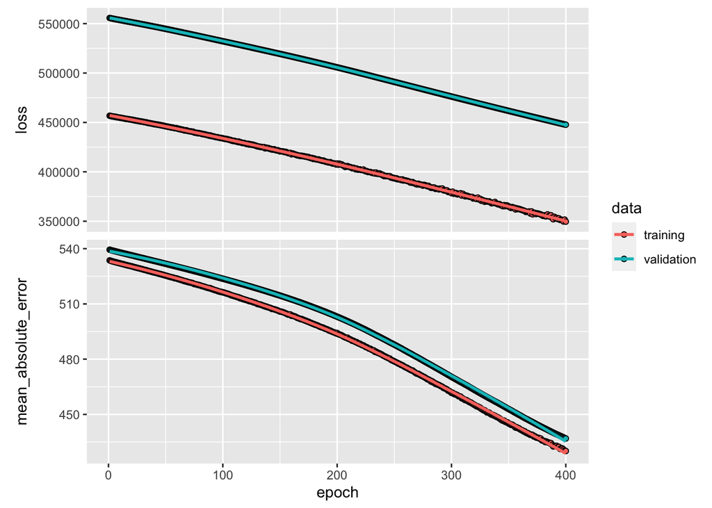

```r
plot(history)
```

## Multi-Layer Neural Networks

We’ll use MNIST dataset provided in the textbook.

This dataset is 60,000 images in the training data and 10,000 in the test data. The images are 28×28, and stored as a three-dimensional array, so we need to reshape them into a matrix.

```r
mnist_file <- "/Users/yeyintwin/Desktop/DM_assign/mnist.npz"

# Load the MNIST dataset from the local file
mnist <- keras::dataset_mnist(path = mnist_file)

#train set for images
train_images <- mnist$train$x

#train set for label
train_labels <- mnist$train$y


#test set for images and label
test_images <- mnist$test$x
test_labels <- mnist$test$y


dim(train_images)
```

```
## [1] 60000    28    28
```

```r
dim(test_images)
```

```
## [1] 10000    28    28
```

```r
train_images <- array_reshape(train_images, c(nrow(train_images), 784))
test_images <- array_reshape(test_images, c(nrow(test_images), 784))
train_labels <- to_categorical(train_labels, 10)
test_labels <- to_categorical(test_labels, 10)

train_images <- train_images / 255
test_images <- test_images / 255
```

Model for multi-layer neural networks using relu twice, and output layer with activation function of “softmax”. The (1st) first layer goes from 28 × 28 = 784 input units to a hidden layer of 256 units, followed with dropout layer to perform regularization. This will have 128 hidden units into the second (2nd) layer, followed with dropout layer. The output layer for this model will have “soft-max” activation for 10-class classification.

```r
modelnn <- keras_model_sequential() %>%
  layer_dense(units = 256, activation = "relu", input_shape = c(784)) %>%
  layer_dropout(rate = 0.4) %>%

  layer_dense(units = 128, activation = "relu") %>%
  layer_dropout(rate = 0.3) %>%

  layer_dense(units = 10, activation = "softmax")

summary(modelnn)
```

```
## Model: "sequential_1"
## ________________________________________________________________________________
##  Layer (type)                       Output Shape                    Param #
## ================================================================================
##  dense_4 (Dense)                    (None, 256)                     200960
##  dropout_2 (Dropout)                (None, 256)                     0
##  dense_3 (Dense)                    (None, 128)                     32896
##  dropout_1 (Dropout)                (None, 128)                     0
##  dense_2 (Dense)                    (None, 10)                      1290
## ================================================================================
## Total params: 235146 (918.54 KB)
## Trainable params: 235146 (918.54 KB)
## Non-trainable params: 0 (0.00 Byte)
## ________________________________________________________________________________
```

The final step is to supply the training data and fit the model. The model will itereate 20 times, and it processes 128 samples at each time. 0.2 of validation_split is so that 20% is used for validation, while the rest, 80%, is for training. Categorical Crossentropy is well-suited for multi-class classification.

```r
modelnn %>% compile(
  loss = "categorical_crossentropy",
  optimizer = optimizer_rmsprop(),
  metrics = c("accuracy")
)

system.time(
  history_nn <- modelnn %>%
    fit(train_images, train_labels, epochs = 20, batch_size = 128,
        validation_split = 0.2)
)
```

```
## 375/375 - 9s - loss: 0.6026 - accuracy: 0.8241 - val_loss: 0.3379 - val_accuracy: 0.9121 - 9s/epoch - 24ms/step
## 375/375 - 8s - loss: 0.8043 - accuracy: 0.8338 - val_loss: 0.4422 - val_accuracy: 0.9103 - 8s/epoch - 21ms/step
## 375/375 - 8s - loss: 1.3253 - accuracy: 0.8142 - val_loss: 0.6611 - val_accuracy: 0.8999 - 8s/epoch - 21ms/step
## 375/375 - 8s - loss: 1.8305 - accuracy: 0.8083 - val_loss: 0.9256 - val_accuracy: 0.8970 - 8s/epoch - 21ms/step
## 375/375 - 8s - loss: 2.3388 - accuracy: 0.7998 - val_loss: 1.0336 - val_accuracy: 0.9003 - 8s/epoch - 22ms/step
## 375/375 - 8s - loss: 2.8041 - accuracy: 0.7947 - val_loss: 1.4267 - val_accuracy: 0.8845 - 8s/epoch - 21ms/step
## 375/375 - 8s - loss: 3.4291 - accuracy: 0.7825 - val_loss: 1.4699 - val_accuracy: 0.8888 - 8s/epoch - 21ms/step
## 375/375 - 8s - loss: 4.1093 - accuracy: 0.7741 - val_loss: 1.8686 - val_accuracy: 0.8766 - 8s/epoch - 21ms/step
## 375/375 - 8s - loss: 4.9055 - accuracy: 0.7664 - val_loss: 2.5895 - val_accuracy: 0.8528 - 8s/epoch - 21ms/step
## 375/375 - 8s - loss: 5.8068 - accuracy: 0.7605 - val_loss: 5.5414 - val_accuracy: 0.7977 - 8s/epoch - 22ms/step
## 375/375 - 8s - loss: 6.5115 - accuracy: 0.7623 - val_loss: 3.9873 - val_accuracy: 0.8272 - 8s/epoch - 22ms/step
## 375/375 - 8s - loss: 7.4567 - accuracy: 0.7583 - val_loss: 3.6984 - val_accuracy: 0.8660 - 8s/epoch - 22ms/step
## 375/375 - 8s - loss: 8.4588 - accuracy: 0.7611 - val_loss: 4.9636 - val_accuracy: 0.8348 - 8s/epoch - 22ms/step
## 375/375 - 8s - loss: 9.3248 - accuracy: 0.7632 - val_loss: 5.8671 - val_accuracy: 0.8493 - 8s/epoch - 21ms/step
## 375/375 - 8s - loss: 10.5710 - accuracy: 0.7610 - val_loss: 6.1305 - val_accuracy: 0.8224 - 8s/epoch - 22ms/step
## 375/375 - 8s - loss: 11.7422 - accuracy: 0.7659 - val_loss: 7.1353 - val_accuracy: 0.8532 - 8s/epoch - 21ms/step
## 375/375 - 8s - loss: 12.9552 - accuracy: 0.7646 - val_loss: 10.1594 - val_accuracy: 0.7945 - 8s/epoch - 21ms/step
## 375/375 - 8s - loss: 14.4175 - accuracy: 0.7646 - val_loss: 7.9768 - val_accuracy: 0.8612 - 8s/epoch - 21ms/step
## 375/375 - 8s - loss: 16.1871 - accuracy: 0.7640 - val_loss: 10.9366 - val_accuracy: 0.8370 - 8s/epoch - 22ms/step
## 375/375 - 8s - loss: 17.9929 - accuracy: 0.7686 - val_loss: 7.2586 - val_accuracy: 0.8789 - 8s/epoch - 22ms/step
```

```
##    user  system elapsed
## 156.932  29.235 162.775
```

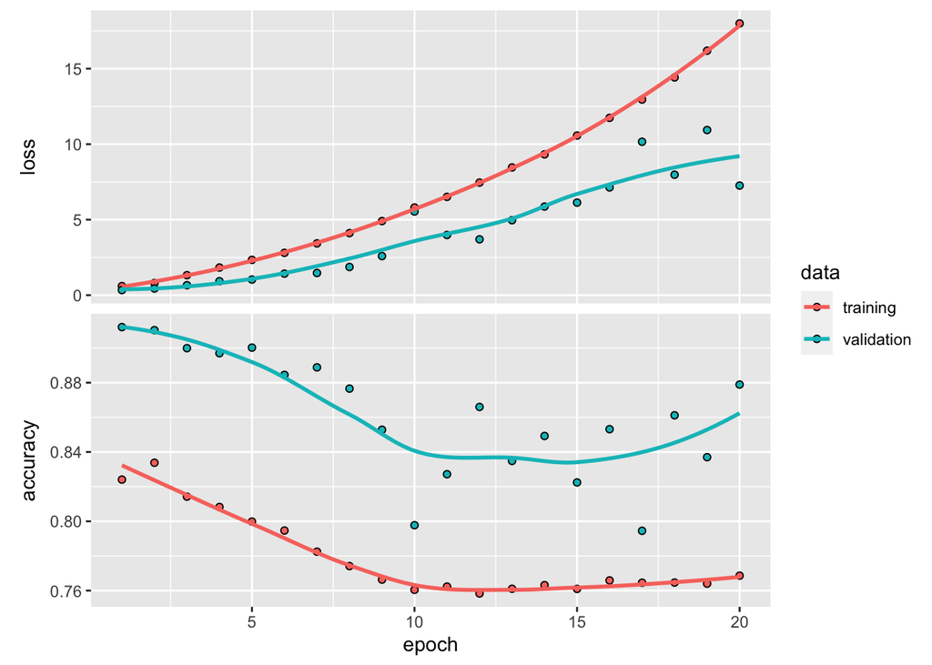

```r
plot(history_nn , smooth = TRUE)
```

accuracy() that compares predicted and true class labels, and this computes the correctly predicted labels out of the total number of labels. k_argmax(): convert the predictions into class labels.

```r
accuracy <- function(pred, truth) {
  mean(drop(as.numeric(pred)) == drop(truth))
}
modelnn %>% predict(test_images) %>% k_argmax() %>% accuracy(test_labels)
```

```
## 313/313 - 1s - 656ms/epoch - 2ms/step
```

```
## [1] 0.10494
```

Now, we’ll model with a single layer to get a comparable model to the multi-layer model above.

Softmax Function: $softmax(f_m(X)) = Pr(Y = m | X) = \frac{e^{Z_m}}{\sum_{l=0}^{k} e^{z_l}}$

For our model specifically $softmax(f_m(X)) = Pr(Y = m | X) = \frac{e^{Z_m}}{\sum_{l=0}^{9} e^{z_l}}$

```r
modellr <- keras_model_sequential() %>%
  layer_dense(input_shape = 784, units = 10,
              activation = "softmax")
summary(modellr)
```

```
## Model: "sequential_2"
## ________________________________________________________________________________
##  Layer (type)                       Output Shape                    Param #
## ================================================================================
##  dense_5 (Dense)                    (None, 10)                      7850
## ================================================================================
## Total params: 7850 (30.66 KB)
## Trainable params: 7850 (30.66 KB)
## Non-trainable params: 0 (0.00 Byte)
## ________________________________________________________________________________
```

```r
modellr %>% compile(loss = "categorical_crossentropy",
                    optimizer = optimizer_rmsprop(),
                    metrics = c("accuracy"))

history_r<- modellr %>% fit(train_images, train_labels, epochs = 20,
                batch_size = 128, validation_split = 0.2)
```

```
## 375/375 - 7s - loss: 0.6696 - accuracy: 0.8339 - val_loss: 0.3608 - val_accuracy: 0.9052 - 7s/epoch - 18ms/step
## 375/375 - 6s - loss: 0.3537 - accuracy: 0.9029 - val_loss: 0.3124 - val_accuracy: 0.9133 - 6s/epoch - 16ms/step
## 375/375 - 6s - loss: 0.3179 - accuracy: 0.9113 - val_loss: 0.2933 - val_accuracy: 0.9197 - 6s/epoch - 16ms/step
## 375/375 - 6s - loss: 0.3020 - accuracy: 0.9160 - val_loss: 0.2850 - val_accuracy: 0.9212 - 6s/epoch - 16ms/step
## 375/375 - 6s - loss: 0.2923 - accuracy: 0.9190 - val_loss: 0.2771 - val_accuracy: 0.9241 - 6s/epoch - 16ms/step
## 375/375 - 6s - loss: 0.2855 - accuracy: 0.9204 - val_loss: 0.2746 - val_accuracy: 0.9252 - 6s/epoch - 17ms/step
## 375/375 - 6s - loss: 0.2806 - accuracy: 0.9221 - val_loss: 0.2745 - val_accuracy: 0.9227 - 6s/epoch - 16ms/step
## 375/375 - 6s - loss: 0.2770 - accuracy: 0.9224 - val_loss: 0.2696 - val_accuracy: 0.9272 - 6s/epoch - 16ms/step
## 375/375 - 6s - loss: 0.2736 - accuracy: 0.9240 - val_loss: 0.2684 - val_accuracy: 0.9269 - 6s/epoch - 16ms/step
## 375/375 - 6s - loss: 0.2707 - accuracy: 0.9251 - val_loss: 0.2663 - val_accuracy: 0.9284 - 6s/epoch - 16ms/step
## 375/375 - 6s - loss: 0.2683 - accuracy: 0.9253 - val_loss: 0.2683 - val_accuracy: 0.9275 - 6s/epoch - 16ms/step
## 375/375 - 6s - loss: 0.2666 - accuracy: 0.9267 - val_loss: 0.2670 - val_accuracy: 0.9271 - 6s/epoch - 16ms/step
## 375/375 - 6s - loss: 0.2647 - accuracy: 0.9272 - val_loss: 0.2649 - val_accuracy: 0.9293 - 6s/epoch - 16ms/step
## 375/375 - 6s - loss: 0.2635 - accuracy: 0.9271 - val_loss: 0.2643 - val_accuracy: 0.9287 - 6s/epoch - 16ms/step
## 375/375 - 6s - loss: 0.2617 - accuracy: 0.9278 - val_loss: 0.2645 - val_accuracy: 0.9294 - 6s/epoch - 16ms/step
## 375/375 - 6s - loss: 0.2605 - accuracy: 0.9276 - val_loss: 0.2633 - val_accuracy: 0.9302 - 6s/epoch - 16ms/step
## 375/375 - 6s - loss: 0.2593 - accuracy: 0.9284 - val_loss: 0.2632 - val_accuracy: 0.9291 - 6s/epoch - 16ms/step
## 375/375 - 6s - loss: 0.2582 - accuracy: 0.9299 - val_loss: 0.2641 - val_accuracy: 0.9289 - 6s/epoch - 16ms/step
## 375/375 - 6s - loss: 0.2571 - accuracy: 0.9295 - val_loss: 0.2628 - val_accuracy: 0.9303 - 6s/epoch - 16ms/step
## 375/375 - 6s - loss: 0.2562 - accuracy: 0.9295 - val_loss: 0.2615 - val_accuracy: 0.9307 - 6s/epoch - 17ms/step
```

Accuracy and Plot for Comparing model

```r
modellr %>% predict(test_images) %>% k_argmax() %>% accuracy(test_labels)
```

```
## 313/313 - 1s - 517ms/epoch - 2ms/step
```

```
## [1] 0.10217
```

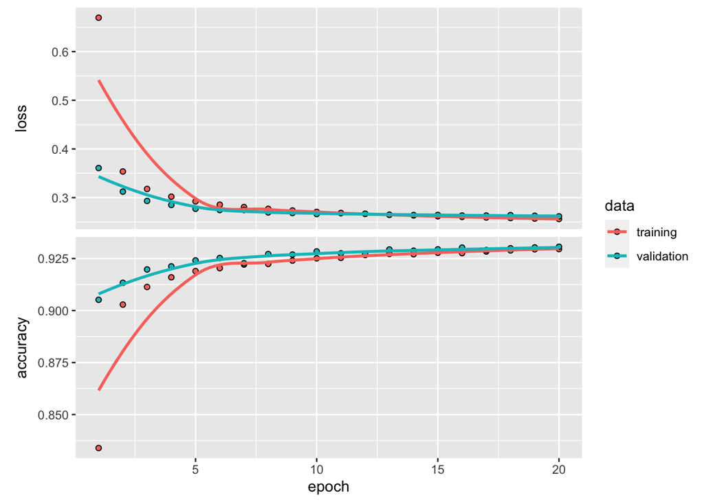

```r
plot(history_r, smooth = TRUE)
```

##### HomeWork:

Here’s a BRCA dataset that is prepared for regression with single-layer neural network.

```r
data(brca)
predictors = data.frame(brca$x)
brca_data = data.frame(x = predictors,
                       y = fct_relevel(brca$y, c("M","B")))
set.seed(42)


n<- nrow(brca_data)

ntest<- trunc(n/3)
testid<- sample(1:n, ntest)
```

1. Fit a linear model to predict `x.radius_mean` and get MAE for the model
2. Make a `glmnet` model and get MAE for the model
3. Make a single-layer neural network with an activation layer of your choice, a dropout layer and output layer.

   Hint: don’t forget scale the inputs.
4. Fit the model and create a plot.
5. Calculate the MAE for this model.

How does this model compare to the previous two models?

Classification/Mutli-Layer Neural Network Homework

```r
# Load datasets
train <- read.csv("https://raw.githubusercontent.com/ben519/MLPB/master/Problems/Classify%20Images%20of%20Stairs/_Data/train.csv")
test <- read.csv("https://raw.githubusercontent.com/ben519/MLPB/master/Problems/Classify%20Images%20of%20Stairs/_Data/test.csv")

# Reshape datasets
train_images <- array_reshape(as.matrix(train[, c("R1C1", "R1C2", "R2C1", "R2C2")]), c(nrow(train), 4))
test_images <- array_reshape(as.matrix(test[, c("R1C1", "R1C2", "R2C1", "R2C2")]), c(nrow(test), 4))
dim(train_images)
```

```
## [1] 400   4
```

```r
dim(test_images)
```

```
## [1] 100   4
```

```r
# Preprocess datasets
train_images <- train_images / 255
test_images <- test_images / 255
```